# DEFENSIVE TRAITS P.lagopus SIBECOL 2025

### P.lagopus - PERIODO DE FRUCTIFICACIÓN

**periodo_fruto ~ trat + clip + trat:clip**

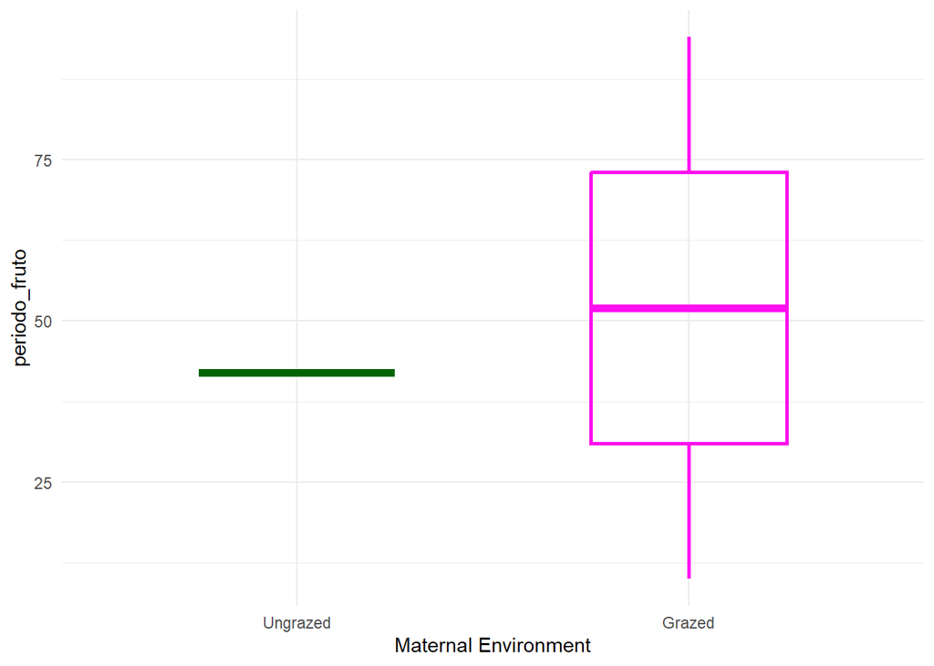

### P.lagopus - dias_fin DE FLORACIÓN

**dias_fin_flor ~ trat + clip + trat:clip**  
n = **3**

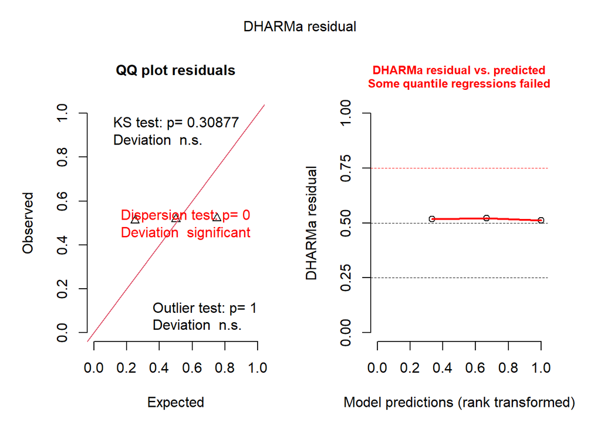

##### PLdias_fin_flor Post-hoc Comparisons with Tukeys HSD

| contrast | trat | estimate | SE | df | z.ratio | p.value |
| --- | --- | --- | --- | --- | --- | --- |
| no - yes | ex | NA | NA | NA | NA | NA |
| no - yes | gra | -0.1571856 | 0.1146857 | Inf | -1.370577 | 0.1705069 |

| contrast | clip | estimate | SE | df | z.ratio | p.value |
| --- | --- | --- | --- | --- | --- | --- |
| ex - gra | no | NA | NA | NA | NA | NA |
| ex - gra | yes | -0.0625204 | 0.1118581 | Inf | -0.5589257 | 0.5762124 |

ANOVA Results for PLdias_fin_flor Model

| Response | Predictor | Chisq | Df | Pr(>Chisq) |
| --- | --- | --- | --- | --- |
| PL dias_fin_flor | trat | 0.312 | 1 | 0.576 |
| PL dias_fin_flor | clip | 1.878 | 1 | 0.171 |
| PL dias_fin_flor | trat:clip | NA | 0 | NA |

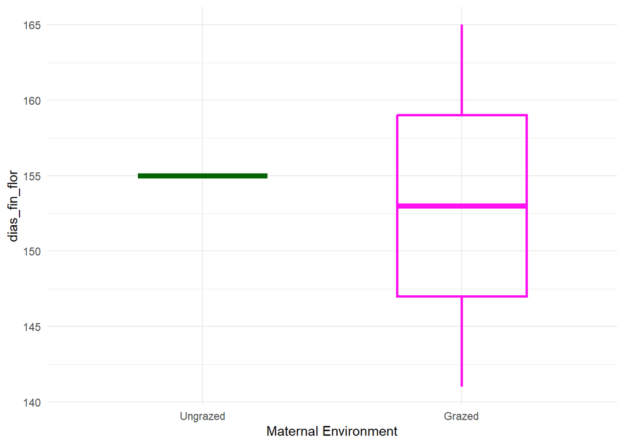

### P.lagopus - dias_fin DE FRUCTIFICACIÓN

**dias_fin_fruto ~ trat + clip + trat:clip**

n = **12**

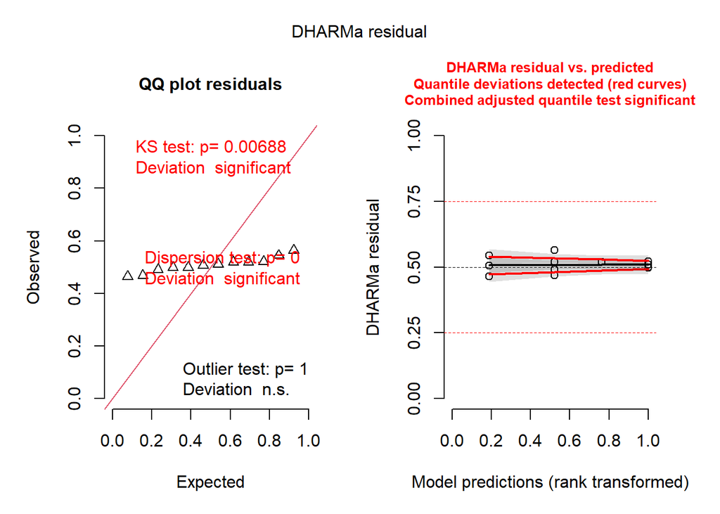

##### PLdias_fin_fruto Post-hoc Comparisons with Tukeys HSD

| contrast | trat | estimate | SE | df | z.ratio | p.value |
| --- | --- | --- | --- | --- | --- | --- |
| no - yes | ex | 0.0000000 | 0.0870388 | Inf | 0.000000 | 1.000000 |
| no - yes | gra | -0.0081137 | 0.0595971 | Inf | -0.136142 | 0.891709 |

| contrast | clip | estimate | SE | df | z.ratio | p.value |
| --- | --- | --- | --- | --- | --- | --- |
| ex - gra | no | 0.0081137 | 0.0595971 | Inf | 0.1361418 | 0.8917092 |
| ex - gra | yes | 0.0000000 | 0.0870388 | Inf | -0.0000001 | 0.9999999 |

ANOVA Results for PLdias_fin_fruto Model

| Response | Predictor | Chisq | Df | Pr(>Chisq) |
| --- | --- | --- | --- | --- |
| PL dias_fin_fruto | trat | 0.013 | 1 | 0.911 |
| PL dias_fin_fruto | clip | 0.013 | 1 | 0.911 |
| PL dias_fin_fruto | trat:clip | 0.006 | 1 | 0.939 |

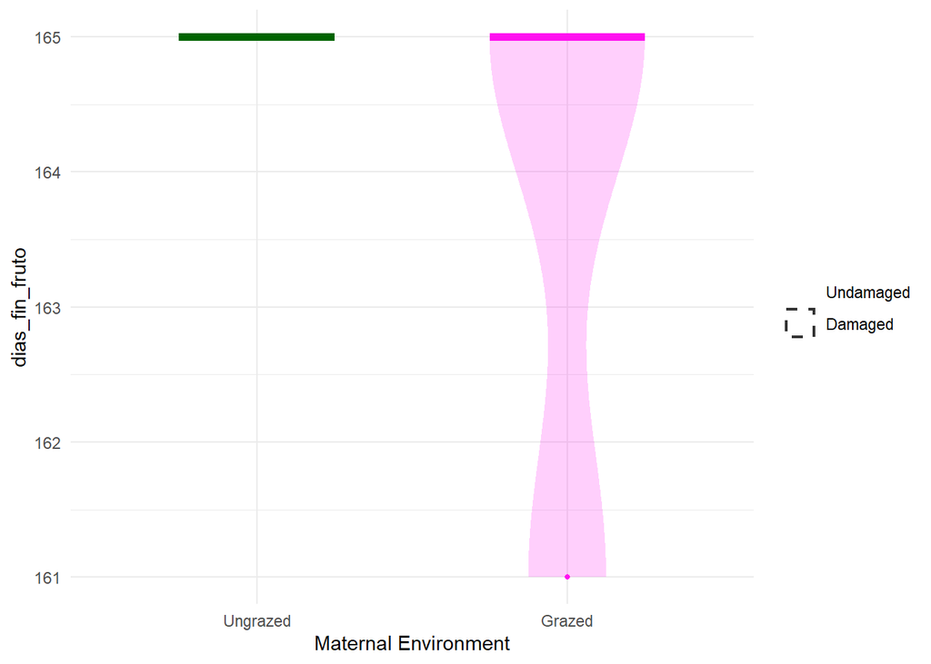

### P.lagopus - ESPERANZA DE VIDA

**dias_muerte ~ trat + clip + trat:clip**  
n = **15**

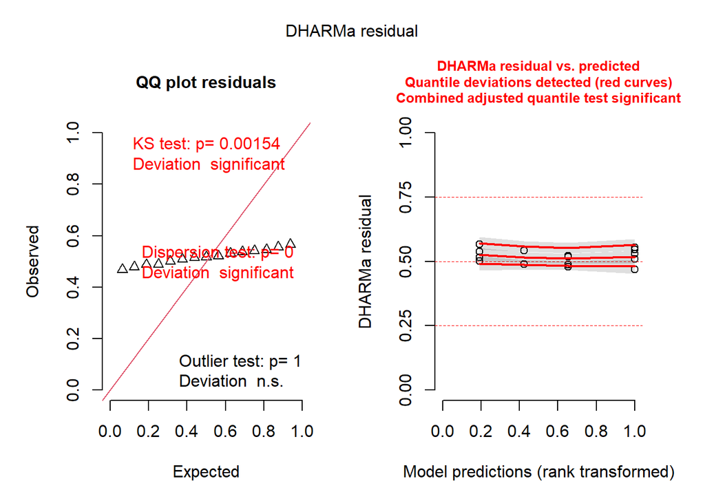

##### PLdias_muerte Post-hoc Comparisons with Tukeys HSD

| contrast | trat | estimate | SE | df | z.ratio | p.value |
| --- | --- | --- | --- | --- | --- | --- |
| no - yes | ex | 0.000000 | 0.0674200 | Inf | 0.0000000 | 1.0000000 |
| no - yes | gra | -0.006079 | 0.0523117 | Inf | -0.1162082 | 0.9074875 |

| contrast | clip | estimate | SE | df | z.ratio | p.value |
| --- | --- | --- | --- | --- | --- | --- |
| ex - gra | no | 0.006079 | 0.0551320 | Inf | 0.1102634 | 0.9122005 |
| ex - gra | yes | 0.000000 | 0.0651339 | Inf | 0.0000000 | 1.0000000 |

ANOVA Results for PLdias_muerte Model

| Response | Predictor | Chisq | Df | Pr(>Chisq) |
| --- | --- | --- | --- | --- |
| PL dias_muerte | trat | 0.007 | 1 | 0.933 |
| PL dias_muerte | clip | 0.008 | 1 | 0.927 |
| PL dias_muerte | trat:clip | 0.005 | 1 | 0.943 |

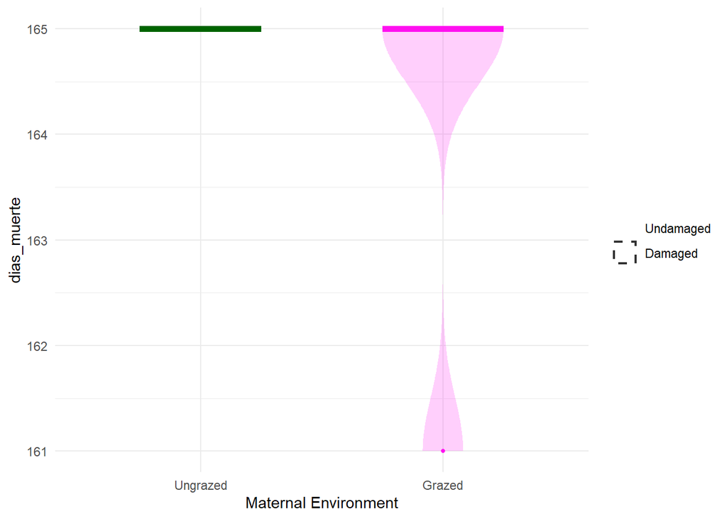

### P.lagopus - FENOLES

**fenoles ~ trat + clip + trat:clip**  
n = **39**

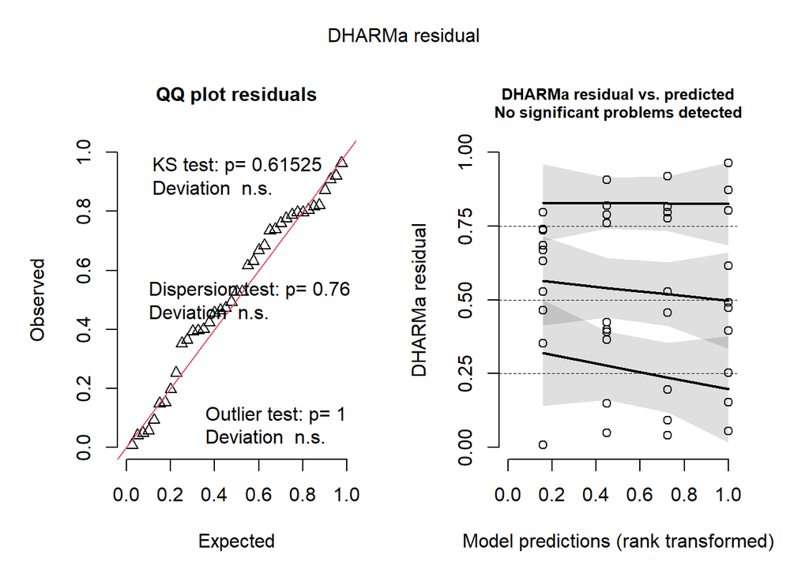

R² = **0.0901008**

##### PLfenoles Post-hoc Comparisons with Tukeys HSD

| contrast | trat | estimate | SE | df | t.ratio | p.value |
| --- | --- | --- | --- | --- | --- | --- |
| no - yes | ex | -21.85122 | 12.57596 | 35 | -1.737540 | 0.0910855 |
| no - yes | gra | -21.21050 | 12.24054 | 35 | -1.732808 | 0.0919341 |

| contrast | clip | estimate | SE | df | t.ratio | p.value |
| --- | --- | --- | --- | --- | --- | --- |
| ex - gra | no | -7.294400 | 12.24054 | 35 | -0.5959215 | 0.5550622 |
| ex - gra | yes | -6.653678 | 12.57596 | 35 | -0.5290792 | 0.6000902 |

ANOVA Results for PLfenoles Model

| Response | Predictor | Sum Sq | Df | F value | Pr(>F) |
| --- | --- | --- | --- | --- | --- |
| PL fenoles | trat | 474.750 | 1 | 0.634 | 0.431 |
| PL fenoles | clip * | 4510.156 | 1 | 6.020 | 0.019 |
| PL fenoles | trat:clip | 0.999 | 1 | 0.001 | 0.971 |
| PL fenoles | Residuals | 26220.384 | 35 | NA | NA |

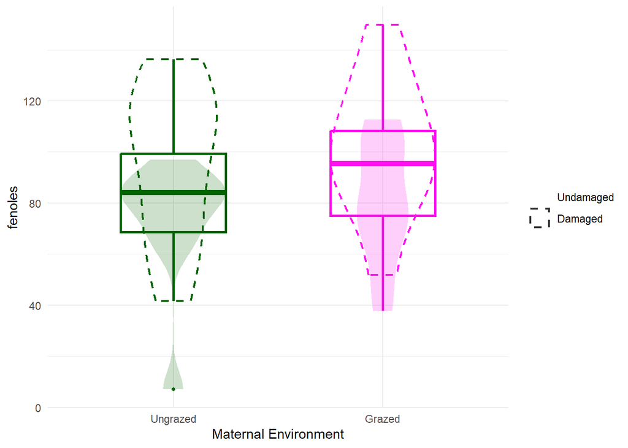

### P.lagopus - BIOMASA

**biomass ~ trat + clip + trat:clip**  
n = **54**

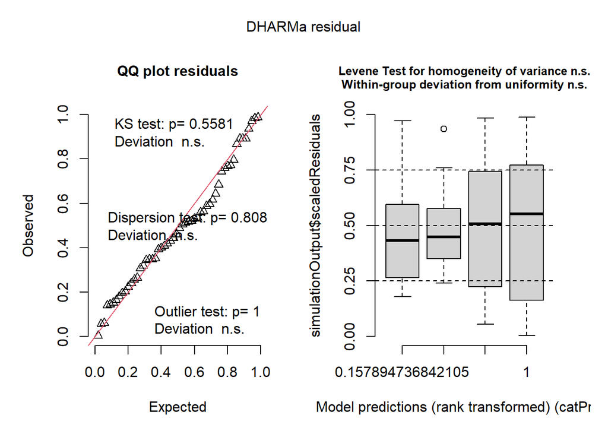

R² = **0.4522842**

##### PLbiomass Post-hoc Comparisons with Tukeys HSD

| contrast | trat | estimate | SE | df | t.ratio | p.value |
| --- | --- | --- | --- | --- | --- | --- |
| no - yes | ex | 0.5679774 | 0.1802803 | 50 | 3.150524 | 0.0027513 |
| no - yes | gra | 1.0261214 | 0.1732077 | 50 | 5.924225 | 0.0000003 |

| contrast | clip | estimate | SE | df | t.ratio | p.value |
| --- | --- | --- | --- | --- | --- | --- |
| ex - gra | no | -0.4157071 | 0.1732077 | 50 | -2.400050 | 0.0201581 |
| ex - gra | yes | 0.0424369 | 0.1802803 | 50 | 0.235394 | 0.8148644 |

ANOVA Results for PLbiomass Model

| Response | Predictor | Sum Sq | Df | F value | Pr(>F) |
| --- | --- | --- | --- | --- | --- |
| PL biomass | trat | 0.516 | 1 | 2.457 | 0.123 |
| PL biomass | clip *** | 8.750 | 1 | 41.664 | 0.000 |
| PL biomass | trat:clip · | 0.705 | 1 | 3.358 | 0.073 |
| PL biomass | Residuals | 10.500 | 50 | NA | NA |

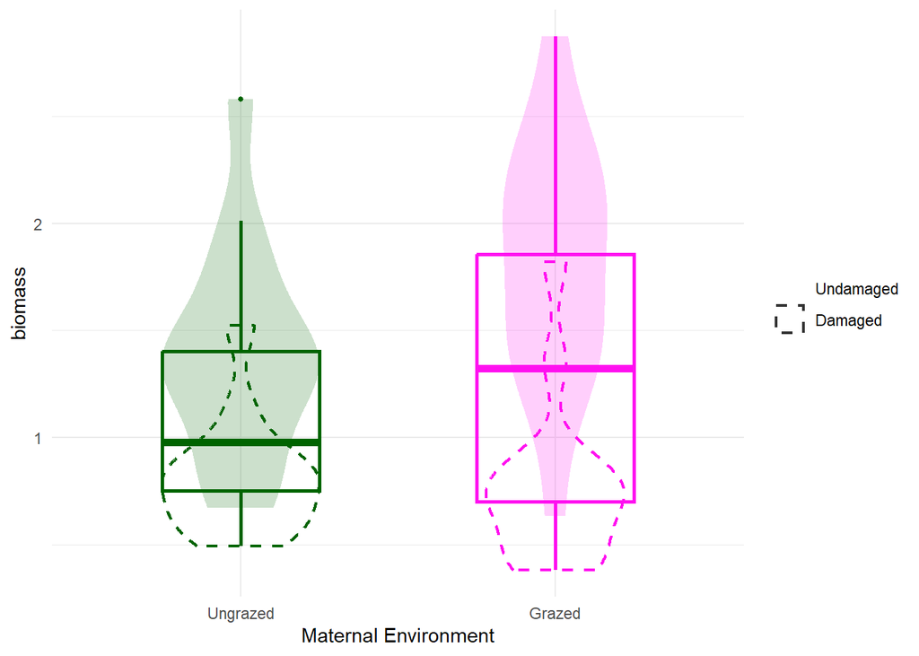

### P.lagopus - Diámetro de la raíz

**AvgDiam.mm. ~ trat + clip + trat:clip**  
n = **40**

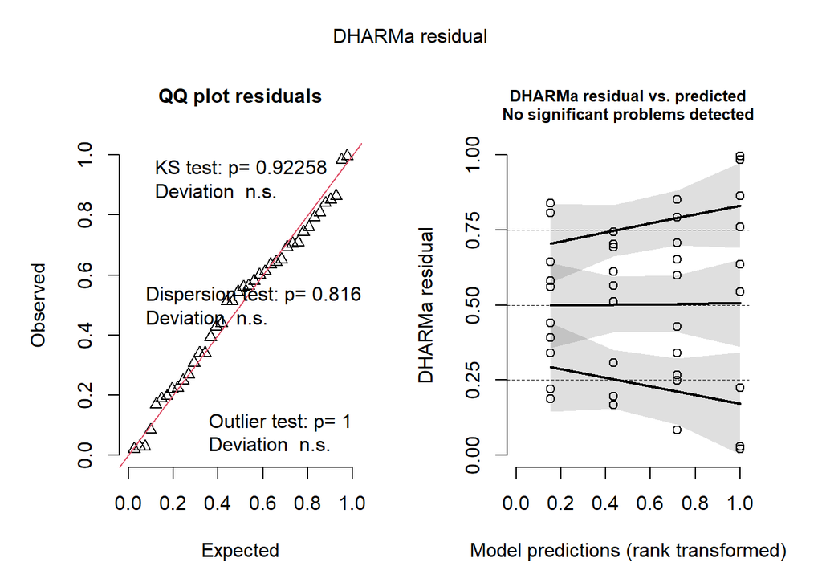

R² = **0.2732762**

##### PLAvgDiam.mm. Post-hoc Comparisons with Tukeys HSD

| contrast | trat | estimate | SE | df | t.ratio | p.value |
| --- | --- | --- | --- | --- | --- | --- |
| no - yes | ex | -0.10948 | 0.0284841 | 36 | -3.843549 | 0.0004747 |
| no - yes | gra | -0.04178 | 0.0284841 | 36 | -1.466784 | 0.1511169 |

| contrast | clip | estimate | SE | df | t.ratio | p.value |
| --- | --- | --- | --- | --- | --- | --- |
| ex - gra | no | -0.01651 | 0.0284841 | 36 | -0.5796218 | 0.5657797 |
| ex - gra | yes | 0.05119 | 0.0284841 | 36 | 1.7971436 | 0.0807063 |

ANOVA Results for PLAvgDiam.mm. Model

| Response | Predictor | Sum Sq | Df | F value | Pr(>F) |
| --- | --- | --- | --- | --- | --- |
| PL AvgDiam.mm. | trat | 0.003 | 1 | 0.741 | 0.395 |
| PL AvgDiam.mm. | clip *** | 0.057 | 1 | 14.100 | 0.001 |
| PL AvgDiam.mm. | trat:clip | 0.011 | 1 | 2.825 | 0.101 |
| PL AvgDiam.mm. | Residuals | 0.146 | 36 | NA | NA |

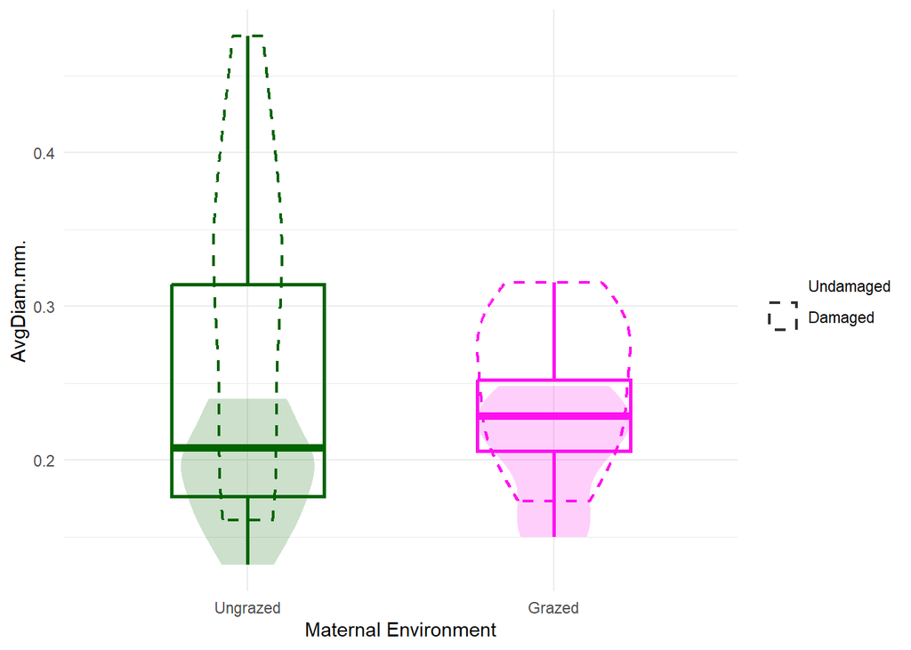

### P.lagopus - Root Tissue Density (RTD)

**RTD ~ trat + clip + trat:clip**  
n = **40**

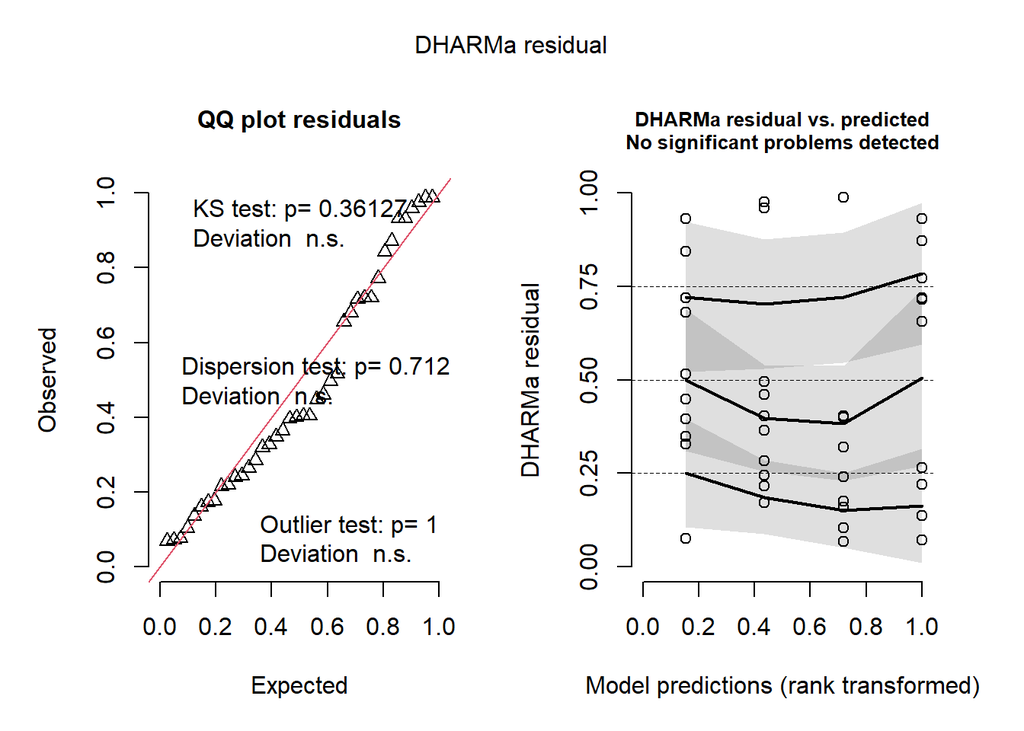

##### PLRTD Post-hoc Comparisons with Tukeys HSD

| contrast | trat | estimate | SE | df | z.ratio | p.value |
| --- | --- | --- | --- | --- | --- | --- |
| no - yes | ex | -0.9243800 | 0.3162297 | Inf | -2.923128 | 0.0034653 |
| no - yes | gra | -0.5470647 | 0.3162297 | Inf | -1.729960 | 0.0836375 |

| contrast | clip | estimate | SE | df | z.ratio | p.value |
| --- | --- | --- | --- | --- | --- | --- |
| ex - gra | no | 0.4558380 | 0.3162297 | Inf | 1.441477 | 0.1494498 |
| ex - gra | yes | 0.8331533 | 0.3162297 | Inf | 2.634646 | 0.0084225 |

ANOVA Results for PLRTD Model

| Response | Predictor | Chisq | Df | Pr(>Chisq) |
| --- | --- | --- | --- | --- |
| PL RTD | trat ** | 8.307 | 1 | 0.004 |
| PL RTD | clip ** | 10.826 | 1 | 0.001 |
| PL RTD | trat:clip | 0.712 | 1 | 0.399 |

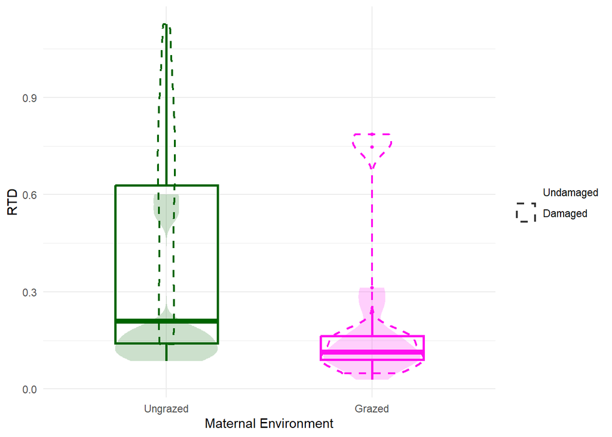

### P.lagopus - Specific Root Length (SRL)

**SRL ~ trat + clip + trat:clip**  
n = **40**

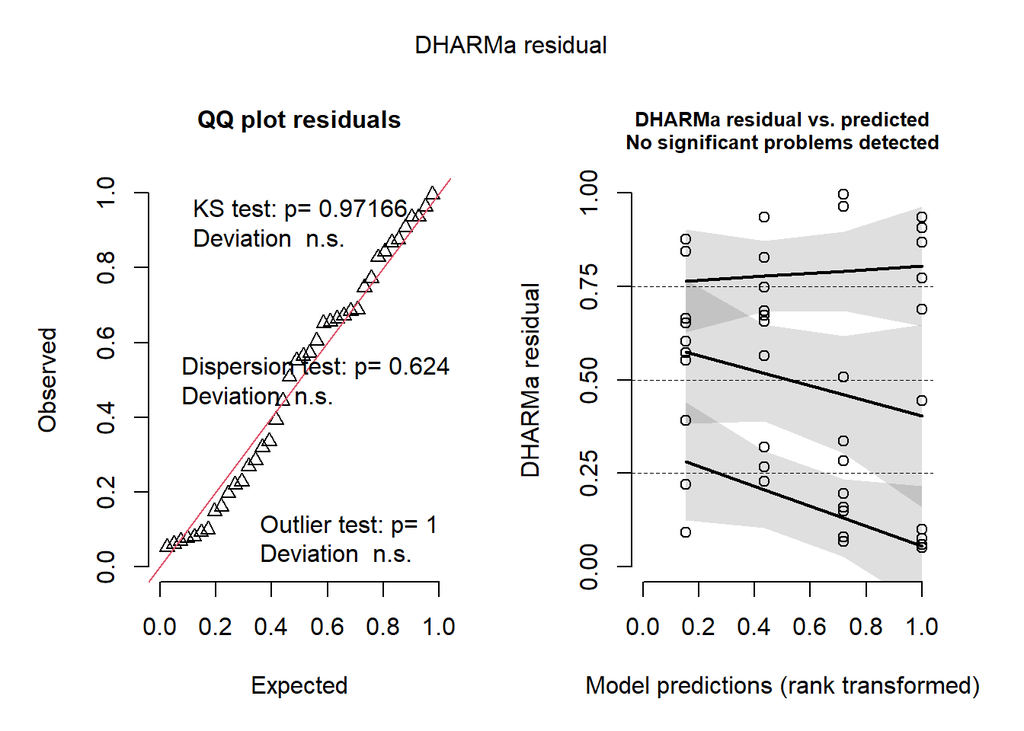

##### PLSRL Post-hoc Comparisons with Tukeys HSD

| contrast | trat | estimate | SE | df | z.ratio | p.value |
| --- | --- | --- | --- | --- | --- | --- |
| no - yes | ex | -2.3071320 | 0.3943518 | Inf | -5.850441 | 0.0000000 |
| no - yes | gra | -0.5794174 | 0.3943520 | Inf | -1.469290 | 0.1417542 |

| contrast | clip | estimate | SE | df | z.ratio | p.value |
| --- | --- | --- | --- | --- | --- | --- |
| ex - gra | no | 0.0824626 | 0.3943520 | Inf | 0.209109 | 0.8343631 |
| ex - gra | yes | 1.8101771 | 0.3943518 | Inf | 4.590259 | 0.0000044 |

ANOVA Results for PLSRL Model

| Response | Predictor | Chisq | Df | Pr(>Chisq) |
| --- | --- | --- | --- | --- |
| PL SRL | trat *** | 11.517 | 1 | 0.001 |
| PL SRL | clip *** | 26.789 | 1 | 0.000 |
| PL SRL | trat:clip ** | 9.597 | 1 | 0.002 |

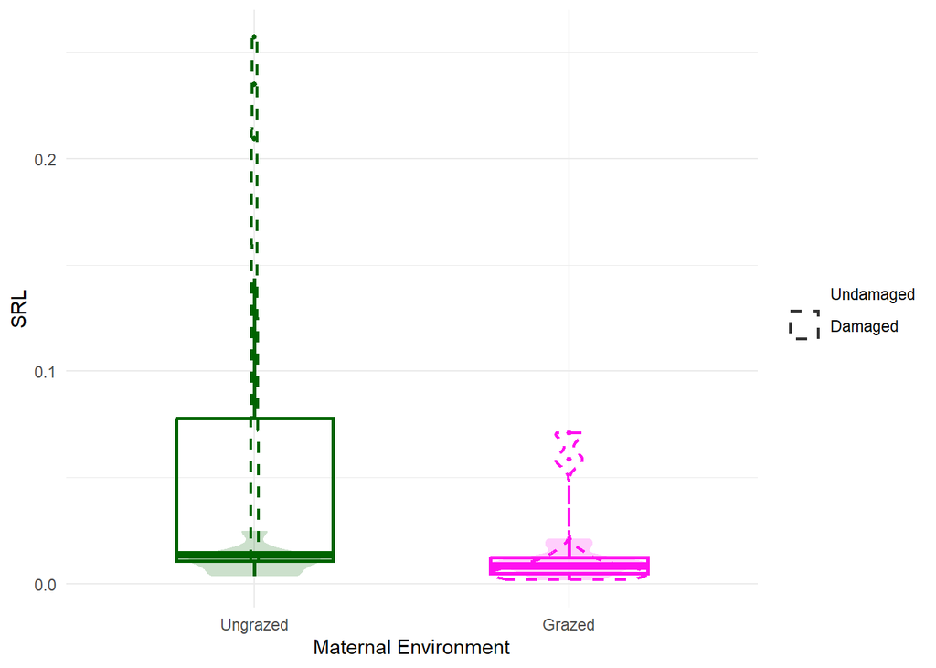